# Gráficas en Python con PIP

## Proyecto CSV

Vamos a correr el proyecto que hicimos en el [curso anterior de Python](https://platzi.com/cursos/python-funciones/).

Vamos a descargar la carpeta app como zip y extraerla en este proyecto.

Recordemos que hicimos la implementación del programa, con los siguientes archivos:

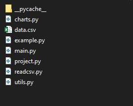

**main.py** contiene el archivo principal donde se ejecuta todo el programa, este contiene los módulos:

- **readcsv.py**: Lee un archivo csv con los datos.
- **charts.py**: Es igual al archivo que creamos antes, que genera una gráfica

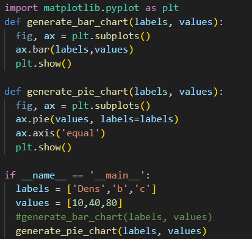

Nos debe quedar así:

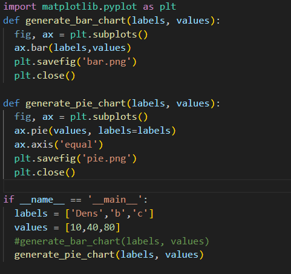

Una vez que hemos modificado todos los archivos de la carpeta app. Vamos a proceder a ejecutar las siguientes lineas de comando en la terminal:

```
#debemos estar en app
pwd

# si no estamos en app, cambiamos a ella
cd py-project/app

#ejecutamos el script de python
python3 main.py
```

Así el programa **main.py** me genera unas imágenes, pero haremos unos ajustes en los códigos porque puede darme errores:

```
country = input('Type Country => ')

  result = utils.population_by_country(data, country)

  if len(result) > 0:
    country = result[0]
    print(country)
    labels, values = utils.get_population(country)
    charts.generate_bar_chart(country, labels, values)
```

Como se puede observar `country` primero se trata como string y después como diccionario, así que se soluciona, poniendo el código así

```
country = input('Type Country => ')
  print(country)

  result = utils.population_by_country(data, country)

  if len(result) > 0:
    country = result[0]
    print(country)
    labels, values = utils.get_population(country)
    charts.generate_bar_chart(country['Country'], labels, values)
```

Y para guardar la imagen, tendremos que usar la siguiente linea, para que se ejecute correctamente:

```
def generate_bar_chart(name, labels, values):
  fig, ax = plt.subplots()
  ax.bar(labels, values)
  plt.savefig(f'./images/{name}-bar.png')
  plt.close()

def generate_pie_chart(labels, values):
  fig, ax = plt.subplots()
  ax.pie(values, labels=labels)
  ax.axis('equal')
  plt.savefig(f'./images/pie.png')
  plt.close()
```

**IMPORTANTE:** La carpeta `images` ya debe estar creado para que el archivo no arroje error.

Ahora mandemos todos los archivos al repositorio de Git Hub. Con los comandos habituales.

```
git add --all
git commit -m "Se agregaron los archivos de la aplicación"
git pull origin main
git push origin main
```